# Stats 20 Homework 8 Solutions

Winter 2022

Edouardo Honig and Michael Tsiang – 123456789

01/12/22

**Note: These solutions are owned by the authors listed above and are intended for personal use only for the students enrolled in Stats 20 in Winter 2022. Any other use is strictly prohibited. Any of these solutions, in whole or in part, may not be posted online or shared with anyone at any time in any form (e.g., verbally, electronically, physically) without explicit written permission by the instructor (Michael Tsiang), *even after the quarter is over*. Failure to comply is facilitating dishonesty and a breach of academic integrity.**

## Question 1

### (a)

```r
college <- read.table(
  "http://www.isi-stats.com/isi/data/chap3/CollegeMidwest.txt", header = TRUE)
head(college)
```

```
##   OnCampus CumGpa
## 1        N   2.92
## 2        N   3.59
## 3        N   3.36
## 4        N   2.47
## 5        N   3.46
## 6        Y   2.98
```

```r
dim(college)
```

```
## [1] 2919    2
```

```r
N <- nrow(college) # population size

set.seed(9999)
xbar_diffs <- replicate(n = 1000, {
  index <- sample(N, size = 30)
  sample_i <- college[index, ]
  with(sample_i, diff(tapply(CumGpa, OnCampus, mean)))
})

## OR

# set.seed(9999)
# xbar_diffs <- numeric(1000)
# for (i in seq_len(1000)) {
#   index <- sample(N, size = 30)
#   sample_i <- college[index, ]
#   xbar_diffs[i] <- with(sample_i, diff(tapply(CumGpa, OnCampus, mean)))
# }
```

### (b)

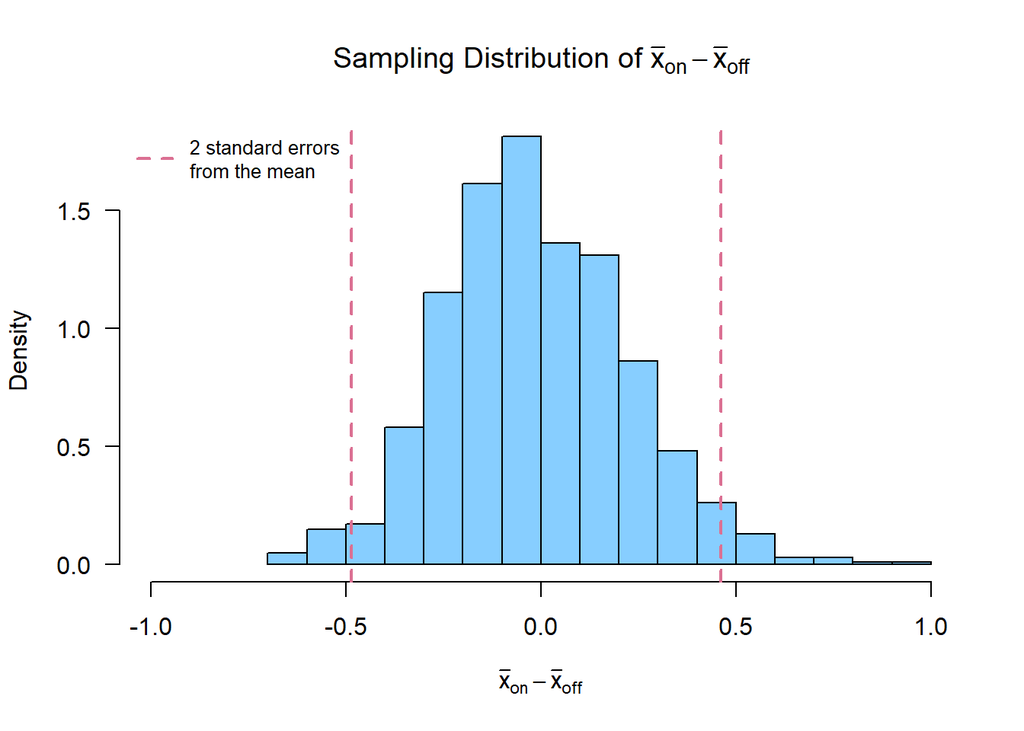

```r
hist(xbar_diffs,
     breaks = 20,
     col = "skyblue1",
     xlim = c(-1, 1),
     las = 1,
     prob = TRUE,
     xlab = expression(bar(x)["on"] - bar(x)["off"]),
     main = expression(paste("Sampling Distribution of ",
                             bar(x)["on"] - bar(x)["off"]))
)
abline(v = mean(xbar_diffs) + (c(-2, 2) * sd(xbar_diffs)),
       lwd = 2,
       lty = 2,
       col = "palevioletred"
)
legend("topleft",
       legend = "2 standard errors\nfrom the mean",
       lwd = 2,
       lty = 2,
       col = "palevioletred",
       cex = 0.8,
       bty = "n"
)
```

### (c)

```r
mean_diff <- mean(xbar_diffs)
mean_diff
```

```
## [1] -0.01290863
```

```r
se_diff <- sd(xbar_diffs)
se_diff
```

```
## [1] 0.2368967
```

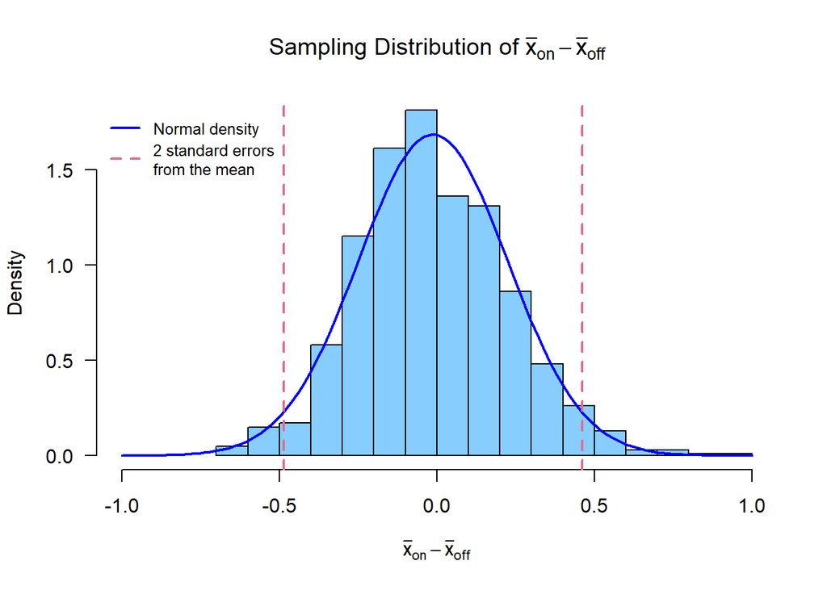

```r
hist(xbar_diffs,
     breaks = 20,
     col = "skyblue1",
     xlim = c(-1, 1),
     las = 1,
     prob = TRUE,
     xlab = expression(bar(x)["on"] - bar(x)["off"]),
     main = expression(paste("Sampling Distribution of ",
                             bar(x)["on"] - bar(x)["off"]))
)
curve(dnorm(x, mean = mean_diff, sd = se_diff), lwd = 2, col = "blue",
      add = TRUE)
abline(v = mean(xbar_diffs) + (c(-2, 2) * sd(xbar_diffs)),
       lwd = 2,
       lty = 2,
       col = "palevioletred"
)
legend("topleft",
       legend = c("Normal density",
                  "2 standard errors\nfrom the mean"),
       lwd = c(2, 2),
       lty = c(1, 2),
       col = c("blue", "palevioletred"),
       cex = 0.8,
       bty = "n"
)
```

### (d)

```r
mean(xbar_diffs > 0.48)
```

```
## [1] 0.026
```

The (approximate) probability of observing a difference in sample means greater than 0.48 is 0.026.

## Question 2

### (a)

```r
set.seed(30)
college_sample <- college[sample(N, size = 30), ]
head(college_sample)
```

```
##      OnCampus CumGpa
## 2378        N   3.33
## 1484        N   3.66
## 1546        N   2.18
## 2363        Y   3.44
## 1866        Y   3.29
## 1053        Y   3.88
```

```r
sample_gpa <- college_sample$CumGpa
```

### (b)

```r
t_obs <- (mean(sample_gpa) - 3.5) / (sd(sample_gpa) / sqrt(length(sample_gpa)))
t_obs
```

```
## [1] -2.137076
```

The observed $t$-statistic of -2.1371 means that the observed sample mean cumulative GPA of 3.298 is 2.1371 standard errors below the expected mean cumulative GPA of 3.5, assuming the null hypothesis that the true mean cumulative GPA of all students at the College of the Midwest is 3.5.

### (c)

```r
t_test <- t.test(sample_gpa, mu = 3.5)
t_test
```

```
##
##  One Sample t-test
##
## data:  sample_gpa
## t = -2.1371, df = 29, p-value = 0.04115
## alternative hypothesis: true mean is not equal to 3.5
## 95 percent confidence interval:
##  3.104681 3.491319
## sample estimates:
## mean of x
##     3.298
```

The $p$-value from our $t$-test is 0.0411538, which is less than the significance level of $\alpha = 0.05$. Thus we would reject the null hypothesis, so we have sufficient evidence to conclude that the true mean cumulative GPA of all students at the College of the Midwest is significantly different from 3.5.

### (d)

```r
mode(t_test)
```

```
## [1] "list"
```

```r
class(t_test)
```

```
## [1] "htest"
```

The class of the `t_test` object is htest and the mode is list. Even though we have never encountered an `htest` class object before, we can extract information from the object using list syntax because it is stored as a list object.

```r
t_test$conf.int
```

```
## [1] 3.104681 3.491319
## attr(,"conf.level")
## [1] 0.95
```

Based on our confidence interval, we are 95% confident that the true mean cumulative GPA of all students at the College of the Midwest is between 3.105 and 3.491. In particular, 3.5 is not inside our interval, so we would reach the same conclusion as in part (c), namely that the hypothesized mean of 3.5 is not plausible based on our data so the true mean cumulative GPA of all students at the College of the Midwest is significantly different from 3.5.